# Kimberly A. Hochstedler Webb

Assistant Professor at [the University of Pittsburgh, Division of General Internal Medicine](https://dom.pitt.edu/dgim/)  
**Pronouns:** she/her

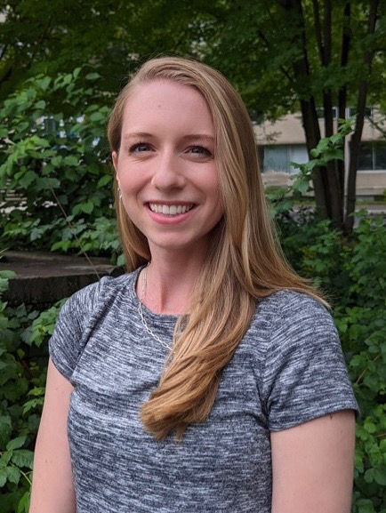

I am an Assistant Professor in the Division of General Internal Medicine at the University of Pittsburgh. I earned my Ph.D. in Statistics from Cornell University in 2024 under the mentorship of [Dr. Martin Wells](https://stat.cornell.edu/people/faculty/martin-wells). I received my MS in Biostatistics from the University of Michigan in 2020 and graduated with my BS in Statistics and Psychology from Carnegie Mellon University in 2018. My current research involves developing statistical methods for misclassified outcome and mediator variables in observational studies. I am interested in applications in healthcare, psychology, and criminal justice.

Please find my CV [here](https://github.com/kimberlywebb/docs/blob/638277bad49e4f596e69ef25b3307079324dbd1f/KAH_Webb_CV.pdf?raw=true).

### My Timeline

[interactive chart not shown]

- **Carnegie Mellon:** BS in [Statistics](http://www.stat.cmu.edu/) and [Psychology](https://www.cmu.edu/dietrich/psychology/index.html) from [Carnegie Mellon University](https://www.cmu.edu/)
- **SIBS:** Student with the [Summer Institute in Biostatistics](https://www.nhlbi.nih.gov/grants-and-training/summer-institute-biostatistics) at the [University of Wisconsin - Madison](https://stat.wisc.edu/)
- **Helgeson Lab:** Member of the [Gender, Relationships, and Health Lab](https://www.cmu.edu/dietrich/psychology/gender-relationships-health/)
- **NIH:** Intern at the National Institutes of Health, in the Epidemiology Branch of the [Eunice Kennedy Shriver National Institute of Child Health and Human Development](https://www.nichd.nih.gov/about/org/diphr/officebranch/eb)
  - Worked with the [Upstate New York Infant Development Screening Program (Upstate KIDS)](https://www.nichd.nih.gov/about/org/diphr/officebranch/eb/infant-development)
- **UMich:** MS in [Biostatistics](https://sph.umich.edu/biostat/) from the [University of Michigan School of Public Health](https://sph.umich.edu/)
- **MROQC:** Statistician with the [Michigan Radiation Oncology Quality Consortium](https://www.mroqc.org/)
- **Cornell:** PhD Student in [Statistics](https://stat.cornell.edu/) at [Cornell University](https://www.cornell.edu/)
- **CTI:** Senior lead fellow in Cornell University’s Center for Teaching Innovation [Graduate Teaching Fellowship](https://teaching.cornell.edu/cti-graduate-teaching-fellowship)
- **rddapp:** Research assistantship with [Felix Thoemmes](https://www.human.cornell.edu/people/fjt36) to update the [“rddapp” R package](https://www.felixthoemmes.com/rddapp/)
- **LinkedIn:** PhD research fellow with the [Bowers CIS Strategic Partnership Program with LinkedIn](https://news.cornell.edu/stories/2022/03/linkedin-cornell-bowers-cis-launch-strategic-partnership)
- **Pitt DGIM:** Assistant Professor in the [Division of General Internal Medicine at the University of Pittsburgh](https://dom.pitt.edu/dgim/)